# The ρ WGD and the spikelet?

# 0. Technical details

- As before, create a directory for your work and navigate to it in R with `setwd("path/to/your/directory")`
- All of the inputs are in `data/`, which you can download from [drive](https://drive.google.com/drive/folders/16PSDpqD0iaAOxukNDMvQ2FA20oqCRJBy?usp=sharing) and place in your working directory.
- We only need `ape` and `ggplot2`, which you already have.
- The slow steps have been done for you: finding collinear blocks in four genomes, estimating Ks for about 50,000 gene pairs, and building the gene trees. Today is focused on interpretation since these steps are time consuming and involve many external bioinformatics tools.
- This is a computer activity and a paper discussion in one, which builds on [Ma et al. (2021)](https://doi.org/10.1093/plcell/koab015) - was the $\rho$ WGD responsible for the spikelet?

# 1. Study system

Last Tuesday we used the grass spikelet as a key innovation and made a big deal about its associations with the $\rho$ whole-genome duplication (WGD) near the origin of grasses. Ma et al. (2021) sequenced the first *Pharus latifolius* genome, which represents the earliest-diverging lineage of grasses with a “true” spikelet, which provides the foundation for this exercise.

Three things from Ma et al. (2021):

1. The *Pharus* genome has evolved slowly, with few rearrangements and little loss of duplicate genes.
2. $\rho$ happened about 98 million years ago, in an ancestor of grasses.
3. *Pharus* and other grasses carry additional pairs of developmental genes, including MADS-box genes, compared to some related species. Expression data backed up the genomic findings.

But how can we be confident that extra pairs of genes came from the $\rho$ WGD and not a small duplication or other episodic event? Last Thursday we had three kinds of evidence for a WGD:

1. **Collinearity.** Ohnologs are duplicated in the same order along chromosomes.
2. **Age of duplicates.** Ohnologs from one WGD share an age, measured as Ks.
3. **Increased duplication from reconciliation.** Many gene trees should show a duplication on the same branch of the species tree.

Today we use all three on the MADS-box genes of seven genomes. Rice and *Brachypodium* are BOP grasses, and sorghum and *Setaria* are PACMAD grasses. *Pharus* is the early grass from the paper. *Joinvillea ascendens* is from Joinvilleaceae, which is sister to Poaceae and did not share $\rho$. *Typha latifolia* (cattail) is more distantly related but a member of the Poales and used here as an outgroup.

Three caveats about this data:

- *Typha* turns out to have a WGD of its own, and that created some complications. *Arabidopsis* is included for the gene tree analyses.
- We ignore Ks values above 3, as we assume they are too old to estimate reliably.
- The MADS-box subfamilies have their own names. LOFSEP is the grass name for the SEP1/2/4 lineage on Tuesday’s ABCE slide.

Here is the species tree used for analyses:

```r
library(ape)       # reading and drawing trees
library(ggplot2)   # plots
theme_set(theme_bw(base_size = 11))

# one colour per species, used in every figure
sp_cols <- c("rice" = "#0072B2", "Brachypodium" = "#56B4E9",
             "sorghum" = "#009E73", "Setaria" = "#009E73",
             "Pharus" = "#E69F00", "Joinvillea" = "#D55E00",
             "Typha" = "#CC79A7", "Arabidopsis" = "grey50")

species_tree <- read.tree("data/species_tree.tre")
plot(species_tree, tip.color = sp_cols[species_tree$tip.label], cex = 0.9)
```

[output not shown]

# 2. Collinearity

The first file has every collinear pair of genes within each of four genomes, found by MCScanX ([Wang et al. 2012](https://doi.org/10.1093/nar/gkr1293)). Each row is two similar genes in the same genome whose neighbours are in the same order, with the chromosome and position (in Mb) of each.

```r
pairs <- read.csv("data/collinear_pairs.csv")
chroms <- read.csv("data/chromosomes.csv")
head(pairs)

# how many collinear pairs, and how many blocks, in each genome?
table(pairs$species)
tapply(pairs$block, pairs$species, function(b) length(unique(b)))
```

Rice should have 3,334 pairs in 146 blocks. On Thursday, PLAZA’s own pipeline found 3,238 pairs in rice, so different approaches arrive at similar results.

A WGD duplicates every chromosome, but then fractionation removes many of the duplicates and returns the chromosome number to diploid state. This process might be biased across the genome though. Are there rice chromosomes that share more collinear genes than others?

```r
rice <- pairs[pairs$species == "rice", ]

# name each pair of chromosomes with the smaller number first, so 5-1 and 1-5 match
low <- pmin(rice$chr_x, rice$chr_y)
high <- pmax(rice$chr_x, rice$chr_y)
rice$chr_pair <- paste(low, high, sep = "-")

# the eight pairs of chromosomes with the most collinear genes
head(sort(table(rice$chr_pair), decreasing = TRUE), 8)
```

Do you have a hypothesis for which chromosomes might share more $\rho$ duplicates?

*Pharus* also has 12 chromosomes. Can you make the same table for *Pharus*? The two chromosome numbers from the two species are named separately, but would you be willing to guess which *Pharus* chromosomes are syntenic with the largest $\rho$-derived chromosomes in rice?

```r
# Give each gene a position along the whole genome: its position on its chromosome
# plus the lengths of all the chromosomes before it.
lay_out <- function(sp) {
  chr <- chroms[chroms$species == sp, ]
  chr$start <- cumsum(chr$mb) - chr$mb
  one <- pairs[pairs$species == sp, ]
  one$x <- one$mb_x + chr$start[match(one$chr_x, chr$chr)]
  one$y <- one$mb_y + chr$start[match(one$chr_y, chr$chr)]
  one
}

# the MADS-box genes in each genome
mads <- read.csv("data/mads_genes.csv")
table(mads$species)

three <- rbind(lay_out("rice"), lay_out("Pharus"), lay_out("Joinvillea"))
# TRUE if either gene in the pair is a MADS-box gene
three$mads <- three$gene_x %in% mads$gene | three$gene_y %in% mads$gene

# where each chromosome ends, for the grid lines
ends <- chroms[chroms$species %in% c("rice", "Pharus", "Joinvillea"), ]
ends$end <- ave(ends$mb, ends$species, FUN = cumsum)

# the order of the panels
panel_order <- c("rice", "Pharus", "Joinvillea")
three$species <- factor(three$species, levels = panel_order)
ends$species <- factor(ends$species, levels = panel_order)
```

Rice should have 36 MADS-box genes. Now the dot plots. Each pair is drawn above and below the diagonal, as on Thursday.

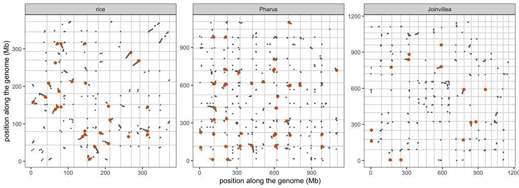

Collinear gene pairs within three genomes. Each grey point is a pair of similar genes in the same order on two stretches of chromosome; vermillion points are pairs that include a MADS-box gene. Light lines mark chromosome boundaries.

```r
ggplot(three, aes(x = x, y = y)) +
  geom_vline(data = ends, aes(xintercept = end), colour = "grey85") +
  geom_hline(data = ends, aes(yintercept = end), colour = "grey85") +
  geom_point(size = 0.2, colour = "grey40") +
  geom_point(aes(x = y, y = x), size = 0.2, colour = "grey40") +
  geom_point(data = three[three$mads, ], colour = "#D55E00", size = 1.6) +
  geom_point(data = three[three$mads, ], aes(x = y, y = x), colour = "#D55E00",
             size = 1.6) +
  facet_wrap(~ species, scales = "free") +
  theme(panel.grid = element_blank()) +
  labs(x = "position along the genome (Mb)", y = "position along the genome (Mb)")
```

How do the three genomes differ? Some of the vermillion MADS-box pairs sit on rice’s long diagonals. Which ones?

```r
rice_mads <- three[three$species == "rice" & three$mads, ]
rice_mads[, c("gene_x", "chr_x", "gene_y", "chr_y", "block")]
```

Which chromosome pairs do they sit on? Are *FUL1* (*OsMADS14*) and *FUL2* (*OsMADS15*), the pair from Tuesday’s slides, among them?

One last number for this section: what percentage of each species genes are still retained in duplicate in a collinear block?

```r
counts <- read.csv("data/gene_counts.csv")
for (sp in c("rice", "Pharus", "Joinvillea")) {
  one <- pairs[pairs$species == sp, ]
  in_pairs <- unique(c(one$gene_x, one$gene_y))     # genes with a collinear partner
  print(c(sp, round(100 * length(in_pairs) / counts$genes[counts$species == sp])))
}
```

# 3. Age of duplicates

Every collinear pair also has a Ks value. Ohnologs from one WGD started diverging at the same time, so they should pile up at one Ks.

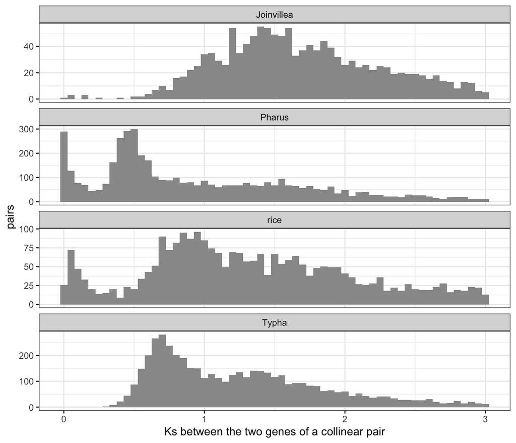

Ks between collinear duplicate genes in four genomes.

```r
# leave out missing values and the saturated tail
has_ks <- !is.na(pairs$ks) & pairs$ks < 3
ggplot(pairs[has_ks, ], aes(x = ks)) +
  geom_histogram(binwidth = 0.05, fill = "grey60") +
  facet_wrap(~ species, ncol = 1, scales = "free_y") +
  labs(x = "Ks between the two genes of a collinear pair", y = "pairs")
```

Do you see one or more *peaks* for each genome? Which genome has no peak young enough to be $\rho$? Rice has two kinds of block from section 2, so let’s look at them separately.

```r
# rice$chr_pair is from section 2
rho_blocks <- c("1-5", "2-4", "2-6", "3-7", "8-9")
median(rice$ks[rice$chr_pair %in% rho_blocks], na.rm = TRUE)
median(rice$ks[rice$chr_pair == "11-12"], na.rm = TRUE)
```

Is the 11–12 block lacking a MADS-box duplicate part of $\rho$?

Now let’s place $\rho$ against the speciation events, using Ks between orthologs (one gene in two species).

```r
orth <- read.csv("data/ortholog_ks.csv")
orth <- orth[orth$ks < 3, ]
sort(tapply(orth$ks, orth$pair, median))
```

Can you fill out the following table from your results so far?

| Comparison | What it dates | Median Ks |
| --- | --- | --- |
| rice ρ blocks | ρ |  |
| rice–sorghum | BOP–PACMAD split |  |
| rice–*Pharus* | *Pharus* split |  |
| rice–*Joinvillea* | grass–*Joinvillea* split |  |
| rice–*Typha* | *Typha* split |  |

Do the orthologs come out in the order of the species tree? Where would you place $\rho$ based on this evidence alone? We can check what happended in Ma et al. (2021) too.

About rate variation: rice, *Pharus* and *Joinvillea* have all had the same amount of time since they split from *Typha*. Can you work out the median ortholog Ks from each of them to *Typha*? (The pairs are called `rice-Typha`, `Pharus-Typha` and `Joinvillea-Typha` in `orth`.) Which lineage has evolved fastest? How could that make a pair of rice paralogs look older than a rice–*Joinvillea* ortholog?

**Q2: If you only had rice, Ks would put ρ before the grasses split from *Joinvillea*. If you only had *Pharus*, it would be a tie. Which would you trust? Our Ks simulations on Thursday used one rate for every lineage. What did that leave out?**

# 4. Reconciliation

The third kind of evidence uses only the gene trees, no rates of evolution.

```r
list.files("data/trees")
```

There is one tree per MADS-box subfamily, 13 total. On Tuesday’s ABCE slide, AP1-FUL holds are the A-class genes, AP3 and PI are the B class, AG are the C and D class, and SEP3 and LOFSEP are the E class. AGL6 is the E class’s closest relative and Bsister genes are expressed in the ovule. The rest mostly control flowering time and roots. Each tree has the genes from all seven genomes plus the *Arabidopsis* members. Most are rooted on *Arabidopsis*. When not possible because *Arabidopsis* was not monophyletic (as in AG), the tree is rooted at its midpoint. Tip labels start with the species.

```r
# draw a gene tree with tips coloured by species and support values on the nodes
plot_gene_tree <- function(subfamily) {
  tr <- read.tree(paste0("data/trees/", subfamily, ".tre"))
  sp <- sub("_.*", "", tr$tip.label)          # "rice_OsMADS3" becomes "rice"
  plot(tr, tip.color = sp_cols[sp], cex = 0.65, main = subfamily)
  # ultrafast bootstrap support (out of 100) for each clade
  nodelabels(tr$node.label, frame = "none", cex = 0.5, adj = c(1.2, -0.3))
}
```

```r
par(mfrow = c(1, 2), mar = c(1, 1, 2, 1))
plot_gene_tree("AG")
plot_gene_tree("LOFSEP")
```

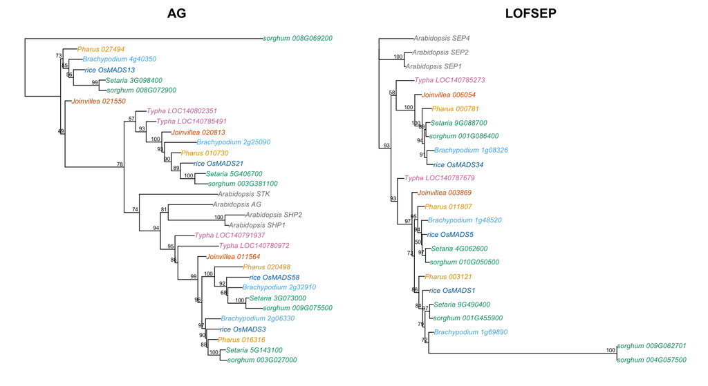

Gene trees of two MADS-box subfamilies. Left: AGAMOUS-like genes. Right: the LOFSEP genes, which include *LHS1* (*OsMADS1*) and *OsMADS5*. Node labels are bootstrap support.

Work through the LCA mapping of the AG gene tree. *OsMADS3* and *OsMADS58* are both rice, so the node joining their two clades is a duplication. Each clade also has a *Pharus* gene and genes from the other grasses. A *Joinvillea* gene is sister to this duplication event. So, for this family and this specific duplciation event, the duplication came after *Joinvillea* split from Poaceae.

Now read the rest yourself. For each tree, find the rice pair, find the node where their copy clades join, and check what sits just outside it.

```r
par(mfrow = c(1, 2), mar = c(1, 1, 2, 1))
plot_gene_tree("PI")      # GLOBOSA-like: OsMADS2 and OsMADS4
plot_gene_tree("SEP3")    # SEPALLATA3-like: OsMADS7 and OsMADS8
```

[output not shown]

```r
plot_gene_tree("AP1-FUL")   # FUL1 (OsMADS14) and FUL2 (OsMADS15)
```

[output not shown]

Can you fill out the following table?

| Subfamily | Rice pair | Support at the duplication | *Pharus* in both copy clades? | Just outside the duplication |
| --- | --- | --- | --- | --- |
| AG | *OsMADS3*, *OsMADS58* | 96 | yes | *Joinvillea* |
| LOFSEP | *OsMADS1* (*LHS1*), *OsMADS5* |  |  |  |
| PI | *OsMADS2*, *OsMADS4* |  |  |  |
| SEP3 | *OsMADS7*, *OsMADS8* |  |  |  |
| AP1-FUL | *OsMADS14*, *OsMADS15* |  |  |  |

Which trees put the duplication on the hypothesized $\rho$ branch? Does the LOFSEP tree have any other duplicates that aren’t from $\rho$? Which tree doesn’t fit the pattern, and where is its *Pharus* gene? Preston and Kellogg ([2006](https://doi.org/10.1534/genetics.106.057125)) found that *FUL1* was lost from early-diverging grasses.

**Q3: In the AG tree, what would the topology look like if the duplication had happened before *Joinvillea* split off? And after *Pharus* split off? The *FUL* pair is collinear in rice, but its tree is ambiguous. Remember Thursday’s think–pair–share on hidden paralogy: which evidence would you weigh more for that pair?**

# 5. Synthesis

The last file brings the evidence together for every duplication that the trees place on the $\rho$ branch. This includes collinearity, its Ks, the tree support, and whether *Joinvillea* is sister.

```r
rho_pairs <- read.csv("data/rho_pairs.csv")
rho_pairs[rho_pairs$species == "rice", ]
rho_pairs[rho_pairs$species == "Pharus", ]
```

Does it agree with your table above? How many MADS-box subfamilies have at least one duplication on the $\rho$ branch?

```r
unique(rho_pairs$subfamily)
length(unique(rho_pairs$subfamily))
```

Each duplication that both grasses kept in pairs appears twice, once in rice and once in *Pharus*. Let’s have a look at their rates of evolution in rice and *Pharus*.

```r
rice_ks <- rho_pairs[rho_pairs$species == "rice", c("duplication", "ks")]
pharus_ks <- rho_pairs[rho_pairs$species == "Pharus", c("duplication", "ks")]

# one row per duplication that both genomes kept in pairs
both <- merge(rice_ks, pharus_ks, by = "duplication", suffixes = c("_rice", "_Pharus"))
both$ratio <- round(both$ks_rice / both$ks_Pharus, 1)
both
```

Which pairs does the tree place on the $\rho$ branch, but synteny doesn’t back up?

```r
rho_pairs[rho_pairs$species == "rice" & !rho_pairs$collinear, ]
```

*LHS1* is expressed in the spikelet. How could a $\rho$ ohnolog end up outside a collinear block?

Finally, did the grasses keep MADS-box genes in pairs more often than other genes on the $\rho$ branch?

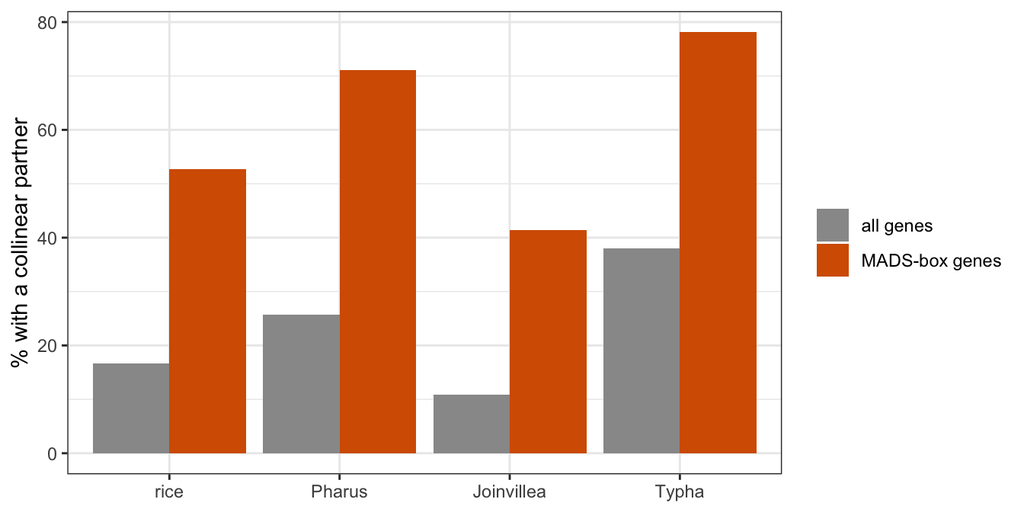

The share of all genes, and of MADS-box genes, that still have a collinear partner in each genome.

```r
retention <- data.frame(species = character(0), genes = character(0),
                        percent = numeric(0))
for (sp in c("rice", "Pharus", "Joinvillea", "Typha")) {
  one <- pairs[pairs$species == sp, ]
  in_pairs <- unique(c(one$gene_x, one$gene_y))     # genes with a collinear partner
  sp_mads <- mads$gene[mads$species == sp]
  all_genes <- counts$genes[counts$species == sp]
  retention <- rbind(retention,
    data.frame(species = sp, genes = "all genes",
               percent = 100 * length(in_pairs) / all_genes),
    data.frame(species = sp, genes = "MADS-box genes",
               percent = 100 * mean(sp_mads %in% in_pairs)))
}
retention

retention$species <- factor(retention$species,
                            levels = c("rice", "Pharus", "Joinvillea", "Typha"))
ggplot(retention, aes(x = species, y = percent, fill = genes)) +
  geom_col(position = "dodge") +
  scale_fill_manual(values = c("all genes" = "grey60", "MADS-box genes" = "#D55E00")) +
  labs(x = NULL, y = "% with a collinear partner", fill = NULL)
```

**Q4: MADS-box genes kept their partners far more often than the genome as a whole. *Typha*, also retains many of its MADS-box pairs from its independent WGD. What does that imply about MADS-box gene retention in general?**

# 6. Takeaways

1. **Three kinds of evidence, mostly one answer.** For most grass MADS-box pairs, synteny and gene trees agree on their status as ρ ohnologs. Ks is squishy,
2. **Synteny shows that a WGD happened, not when.** Ages can help place this and reconcilation can help when we lack confidence in ages.
3. **Rate variation can reorder events.** Ks from a fast genome put ρ in the wrong place. The trees, which ignore rates, didn’t. There are corrections for rate variation but beyond the scope of today.
4. **Retention fits dosage balance, but doesn’t alone tie ρ to the spikelet.** The cattail kept its MADS-box pairs too. The additional evidence from expression patterns and functional work of Mat et al. (2021) are important here.